# rprimer

Sofia Persson

18 september 2021

#### Package

rprimer 0.99.0

# 1 Introduction

The rprimer package provides tools for analyzing sequence conservation and designing degenerate oligos (primers and probes) from a multiple DNA sequence alignment.

In this vignette, I describe and demonstrate how to use the package by designing broadly reactive primers and probes for PCR-based amplification and detection of hepatitis E virus (HEV), a sequence variable RNA virus and a common foodborne pathogen.

# 2 Installation

The package can be installed from [GitHub](https://github.com/) with:

```r
if (!requireNamespace("devtools", quietly = TRUE))
    install.packages("devtools")
devtools::install_github("sofpn/rprimer")
```

# 3 Overview

The design workflow consists of five functions:

- `consensusProfile()`
- `oligos()`
- `assays()`
- `checkMatch()`
- `plotData()`

# 4 Shiny application

The package can be run through a Shiny application. It is loaded by:

- `runRprimerApp()`

# 5 Workflow

## 5.1 Collection of target sequences and multiple alignment

The first step is to identify and align target sequences of interest. It is important that the alignment accurately represents the generic variation of the target population and does not contain any poorly aligned sequences.

The file “example_alignment.txt” is provided with the package and contains an alignment of 198 HEV sequences. The file path can be retrieved by:

```r
system.file("extdata", "example_alignment.txt", package = "rprimer")
```

## 5.2 Data import

The alignment must be imported to R using the `readDNAMultipleAlignment()` function from Biostrings (Pagès et al. 2020). The input file can contain from one to several thousand sequences.

Below, I show how to import the file “example_alignment.txt”:

```r
filepath <- system.file("extdata", "example_alignment.txt", package = "rprimer")

myAlignment <- Biostrings::readDNAMultipleAlignment(filepath, format = "fasta")
```

For some applications, there is often an interest in amplifying a specific region of the genome. In such cases, the alignment can be masked so that only the desired oligo binding regions are available for the subsequent design process. This type of masking can be achieved by using `colMask()` from Biostrings (Pagès et al. 2020):

```r
## Mask everything but position 3000 to 4000 and 5000 to 6000
myMaskedAlignment <- myAlignment

Biostrings::colmask(myMaskedAlignment, invert = TRUE) <- c(3000:4000, 5000:6000)
```

It is also possible to mask specific sequences by using `rowMask()`, and gap-rich positions can be hidden with `gapMask()` (Pagès et al. 2020).

## 5.3 Design process

### 5.3.1 Step 1: `consensusProfile`

Once the alignment is imported, a consensus profile can be generated. The consensus profile will contain all the information needed for the subsequent design process:

- Proportion of the letters A, C, G, T, and “other”
- Proportion of gaps (-)
- Majority consensus base: the most frequently occurring letter among the letters A, C, G, T and -
- Identity: the proportion of sequences, among all sequences with a DNA base (A, C, G, T) or gap (-) that has the majority consensus base
- IUPAC consensus character, including all DNA bases that occur at a relative frequency higher than a user-specified ambiguity threshold. The threshold can range from 0 to 0.2; a value of 0 (default) will catch all the variation, but with the potential downside of generating oligos with high degeneracy, whereas a higher value will capture most of the variation, but with the potential downside of missing less common sequence variants
- Shannon entropy: a measurement of variability (Shannon 1951). It is calculated among all DNA bases that occur at the specific position. A value of 0 indicates complete conservation among these bases, and a high value indicates high variability
- Coverage: proportion of sequences in the target alignment (among all sequences with a DNA base) that are covered by the IUPAC consensus character

`consensusProfile()` has two arguments:

- `x`: a `Biostrings::MultipleDNAAlignment` object (see Data import)
- `ambiguityThreshold`: position wise “detection level” for ambiguous bases. All DNA bases that occur with a proportion higher than the specified value will be included in the IUPAC consensus character. Defaults to `0`, can range from `0` to `0.2`

```r
myConsensusProfile <- consensusProfile(myAlignment, ambiguityThreshold = 0.05)
```

Results (row 100-110):

| position | a | c | g | t | other | gaps | majority | identity | iupac | entropy | coverage |
| --- | --- | --- | --- | --- | --- | --- | --- | --- | --- | --- | --- |
| 100 | 0.00 | 1.00 | 0.00 | 0.00 | 0.00 | 0 | C | 1.00 | C | 0.00 | 1.00 |
| 101 | 0.09 | 0.01 | 0.00 | 0.90 | 0.00 | 0 | T | 0.90 | W | 0.48 | 0.99 |
| 102 | 1.00 | 0.00 | 0.00 | 0.00 | 0.00 | 0 | A | 1.00 | A | 0.00 | 1.00 |
| 103 | 0.00 | 1.00 | 0.00 | 0.00 | 0.00 | 0 | C | 1.00 | C | 0.00 | 1.00 |
| 104 | 0.01 | 0.08 | 0.00 | 0.91 | 0.00 | 0 | T | 0.91 | Y | 0.49 | 0.99 |
| 105 | 0.00 | 0.00 | 1.00 | 0.00 | 0.00 | 0 | G | 1.00 | G | 0.00 | 1.00 |
| 106 | 0.00 | 0.99 | 0.00 | 0.01 | 0.00 | 0 | C | 0.99 | C | 0.05 | 0.99 |
| 107 | 0.00 | 0.64 | 0.01 | 0.35 | 0.01 | 0 | C | 0.64 | Y | 0.98 | 0.99 |
| 108 | 0.99 | 0.00 | 0.01 | 0.00 | 0.00 | 0 | A | 0.99 | A | 0.05 | 0.99 |
| 109 | 0.00 | 0.00 | 0.00 | 1.00 | 0.00 | 0 | T | 1.00 | T | 0.00 | 1.00 |
| 110 | 0.00 | 0.08 | 0.00 | 0.92 | 0.00 | 0 | T | 0.92 | Y | 0.41 | 1.00 |

The results can be visualized by using `plotData()`:

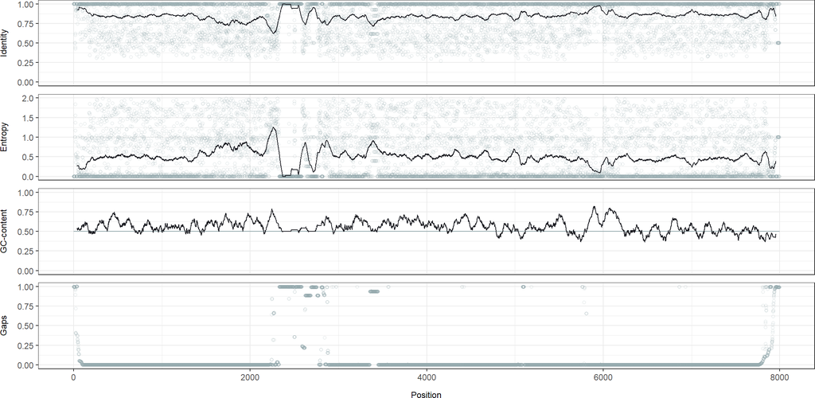

```r
plotData(myConsensusProfile)
```

The dots represent the value at each position, and the black lines show centered running averages. High identity and low entropy values (in combination with low gap values) indicate high sequence conservation.

The data can be explored in more detail by zooming into a specific region of interest:

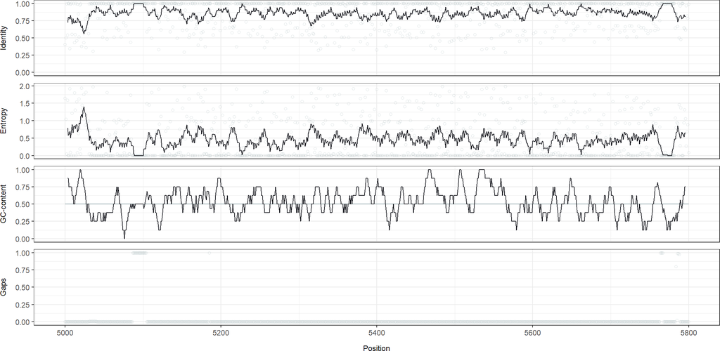

```r
## Select position 5000 to 5800 in the consensus profile
selection <- myConsensusProfile[
  myConsensusProfile$position >= 5000 & myConsensusProfile$position <= 5800,
  ]

plotData(selection)
```

The nucleotide distribution can be displayed by specifying `type = nucleotide`:

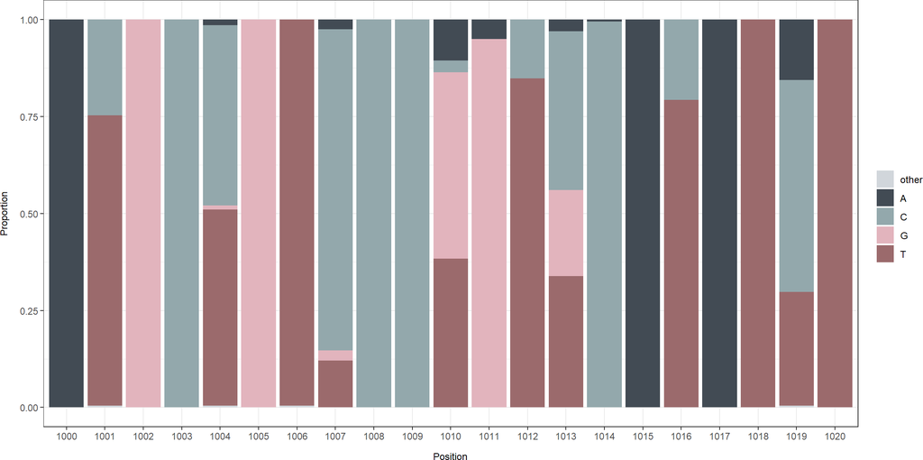

```r
## Select position 1000 to 1020 in the consensus profile
ntSelection <- myConsensusProfile[
  myConsensusProfile$position >= 1000 & myConsensusProfile$position <= 1020,
]

plotData(ntSelection, type = "nucleotide")
```

An alignment with masked columns will be represented as follows:

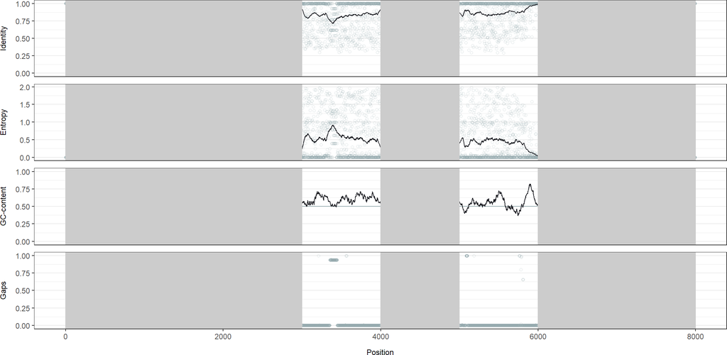

```r
myMaskedConsensusProfile <- consensusProfile(myMaskedAlignment, ambiguityThreshold = 0.05)

plotData(myMaskedConsensusProfile)
```

### 5.3.2 Step 2: `oligos`

The next step is to design oligos. Primers must be designed, and probes are optional. Primers can be generated by using one of the two following strategies:

- The **ambiguous strategy** (default) generates primers from the IUPAC consensus sequence, which means that ambiguous bases can occur at any position in the primer
- The **mixed strategy** generates primers from both the majority and the IUPAC consensus sequence. These primers consist of a shorter degenerate part at the 3’ end (~1/3 of the primer, targeting a conserved region) and a longer consensus part at the 5’ end (~2/3 of the primer), which instead of having ambiguous bases, contains the most probable nucleotide at each position. This strategy resembles the Consensus-Degenerate Hybrid Oligonucleotide Primer (CODEHOP) principle (Rose et al. 1998). It aims to allow amplification of highly variable targets using primers with low degeneracy. The idea is that the degenerate 3’ end part will bind specifically to the target sequence in the initial PCR cycles and promote amplification despite eventual mismatches at the 5’ consensus part (since 5’ end mismatches are generally less detrimental than 3’ end mismatches) (Rose et al. 1998). In this way, the generated products will perfectly match the 5’ ends of all primers, allowing them to be efficiently amplified in later PCR cycles. To provide a sufficiently high melting temperature (tm) with eventual 5’ end mismatches, it is recommended to design relatively long primers (at least 25 bases) when using this strategy

Probes are always designed using the ambiguous strategy.

All sequence variants of an oligo must fulfill all specified design constraints to be considered.

In addition, oligos with at least one sequence variant containing more than four consecutive runs of the same nucleotide (e.g. “AAAAA”) and/or more than three consecutive runs of the same di-nucleotide (e.g. “TATATATA”) are excluded from consideration.

An error message will return if no oligos are found. If so, a good idea could be to re-run the process from Step 1 and increase the `ambiguityThreshold` in `consensusProfile()`, and/or relax the design constraints above.

**Design with default settings**

```r
myOligos <- oligos(myConsensusProfile)
```

Results (first ten rows):

| type | fwd | rev | start | end | length | iupacSequence | iupacSequenceRc | identity | coverage | degeneracy | gcContentMean | gcContentRange | tmMean | tmRange | deltaGMean | deltaGRange | sequence | sequenceRc | gcContent | tm | deltaG | method | score | roiStart | roiEnd |
| --- | --- | --- | --- | --- | --- | --- | --- | --- | --- | --- | --- | --- | --- | --- | --- | --- | --- | --- | --- | --- | --- | --- | --- | --- | --- |
| probe | TRUE | TRUE | 138 | 157 | 20 | TCYGCCYTGGCGAATGCTGT | ACAGCATTCGCCARGGCRGA | 0.96 | 1 | 4 | 0.60 | 0.10 | 63.17 | 4.33 | -21.61 | 2.08 | TCCGCCCT…. | ACAGCATT…. | 0.65, 0….. | 65.33623…. | -22.6538…. | ambiguous | 2 | 1 | 7997 |
| probe | FALSE | TRUE | 141 | 160 | 20 | GCCYTGGCGAATGCTGTGGT | ACCACAGCATTCGCCARGGC | 0.98 | 1 | 2 | 0.62 | 0.05 | 63.18 | 1.84 | -21.73 | 0.83 | GCCCTGGC…. | ACCACAGC…. | 0.65, 0.6 | 64.10586…. | -22.1475…. | ambiguous | 3 | 1 | 7997 |
| primer | TRUE | FALSE | 142 | 160 | 19 | CCYTGGCGAATGCTGTGGT | ACCACAGCATTCGCCARGG | 0.98 | 1 | 2 | 0.61 | 0.05 | 61.48 | 1.95 | -19.84 | 0.83 | CCCTGGCG…. | ACCACAGC…. | 0.631578…. | 62.45335…. | -20.2570…. | ambiguous | 3 | 1 | 7997 |
| probe | TRUE | TRUE | 142 | 160 | 19 | CCYTGGCGAATGCTGTGGT | ACCACAGCATTCGCCARGG | 0.98 | 1 | 2 | 0.61 | 0.05 | 60.45 | 1.94 | -19.84 | 0.83 | CCCTGGCG…. | ACCACAGC…. | 0.631578…. | 61.41686…. | -20.2570…. | ambiguous | 3 | 1 | 7997 |
| primer | TRUE | FALSE | 143 | 160 | 18 | CYTGGCGAATGCTGTGGT | ACCACAGCATTCGCCARG | 0.98 | 1 | 2 | 0.58 | 0.06 | 59.19 | 2.04 | -18.35 | 0.83 | CCTGGCGA…. | ACCACAGC…. | 0.611111…. | 60.20693…. | -18.7709…. | ambiguous | 2 | 1 | 7997 |
| probe | TRUE | TRUE | 143 | 160 | 18 | CYTGGCGAATGCTGTGGT | ACCACAGCATTCGCCARG | 0.98 | 1 | 2 | 0.58 | 0.06 | 58.11 | 2.03 | -18.35 | 0.83 | CCTGGCGA…. | ACCACAGC…. | 0.611111…. | 59.12650…. | -18.7709…. | ambiguous | 2 | 1 | 7997 |
| probe | TRUE | TRUE | 5852 | 5869 | 18 | TTYTGCCTATGYTGCCCG | CGGGCARCATAGGCARAA | 0.97 | 1 | 4 | 0.56 | 0.11 | 56.64 | 3.88 | -17.68 | 1.69 | TTCTGCCT…. | CGGGCAGC…. | 0.611111…. | 58.57438…. | -18.5191…. | ambiguous | 2 | 1 | 7997 |
| probe | TRUE | FALSE | 5852 | 5870 | 19 | TTYTGCCTATGYTGCCCGC | GCGGGCARCATAGGCARAA | 0.97 | 1 | 4 | 0.58 | 0.11 | 59.73 | 3.64 | -19.57 | 1.69 | TTCTGCCT…. | GCGGGCAG…. | 0.631578…. | 61.55498…. | -20.4095…. | ambiguous | 2 | 1 | 7997 |
| probe | TRUE | TRUE | 5852 | 5871 | 20 | TTYTGCCTATGYTGCCCGCG | CGCGGGCARCATAGGCARAA | 0.98 | 1 | 4 | 0.60 | 0.10 | 62.21 | 3.42 | -21.39 | 1.69 | TTCTGCCT…. | CGCGGGCA…. | 0.65, 0….. | 63.91303…. | -22.2315…. | ambiguous | 2 | 1 | 7997 |
| primer | TRUE | FALSE | 5926 | 5945 | 20 | GGCRGTGGTTTCTGGGGTGA | TCACCCCAGAAACCACYGCC | 0.98 | 1 | 2 | 0.62 | 0.05 | 62.84 | 2.51 | -20.86 | 1.25 | GGCAGTGG…. | TCACCCCA…. | 0.6, 0.65 | 61.57995…. | -20.2350…. | ambiguous | 3 | 1 | 7997 |

The manual (`?oligos`) contains a detailed description of each variable, but what may not be completely self-explanatory is that some variables (e.g. `sequence` `gcContent` and `tm`) can hold several values in each entry. All values within a specific row can be retrieved by:

```r
myOligos$sequence[[1]] ## All sequence variants of the first oligo (i.e., first row)
```

```
#> [1] "TCCGCCCTGGCGAATGCTGT" "TCTGCCCTGGCGAATGCTGT" "TCCGCCTTGGCGAATGCTGT"
#> [4] "TCTGCCTTGGCGAATGCTGT"
```

```r
myOligos$gcContent[[1]] ## GC-content of all variants of the first oligo
```

```
#> [1] 0.65 0.60 0.60 0.55
```

```r
myOligos$tm[[1]] ## Tm of all variants of the first oligo
```

```
#> [1] 65.33624 62.86736 63.47792 61.00290
```

The primer and probe candidates can be visualized using `plotData()`:

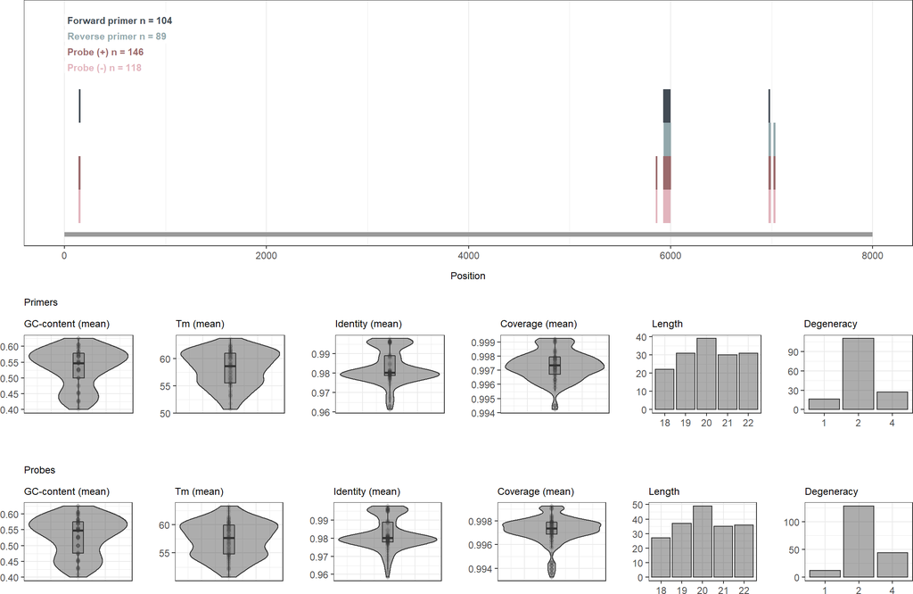

```r
plotData(myOligos)
```

**Design with modified settings**

Below, I show how to modify some of the design constraints.

```r
myOligosModified <- oligos(myConsensusProfile,
                           maxDegeneracyPrimer = 32,
                           tmPrimer = c(50, 70),
                           lengthPrimer = c(16, 24),
                           maxDegeneracyProbe = 1)
```

There are now more primer candidates (due to relaxed constraints) and less probe candidates (due to tighter constraints).

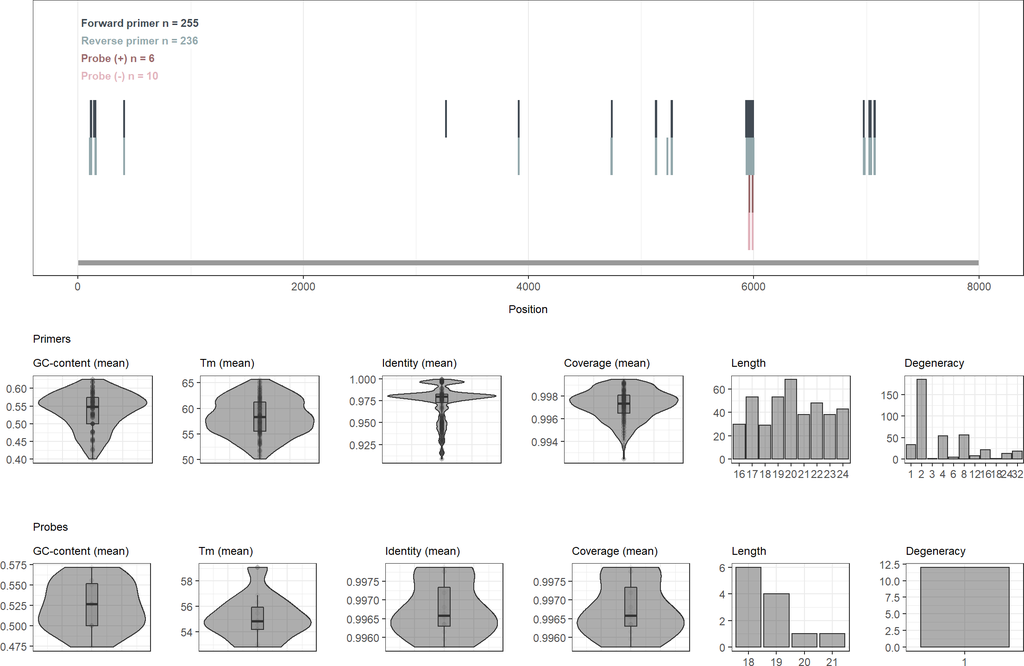

```r
plotData(myOligosModified)
```

**Mixed primers**

Now, I show how to design mixed primers. In this case, I select to not design probes.

```r
myMixedPrimers <- oligos(myConsensusProfile,
                         designStrategyPrimer = "mixed",
                         probe = FALSE)
```

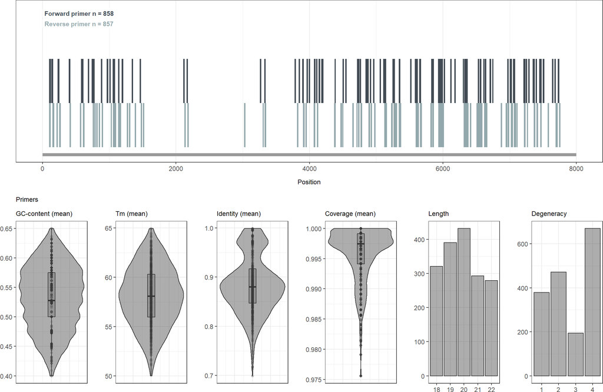

```r
plotData(myMixedPrimers)
```

As a comparison, I do the same for the dataset where I masked all positions but 3000 to 4000 and 5000 to 6000:

```r
myMaskedMixedPrimers <- oligos(myMaskedConsensusProfile,
                               designStrategyPrimer = "mixed",
                               probe = FALSE)
```

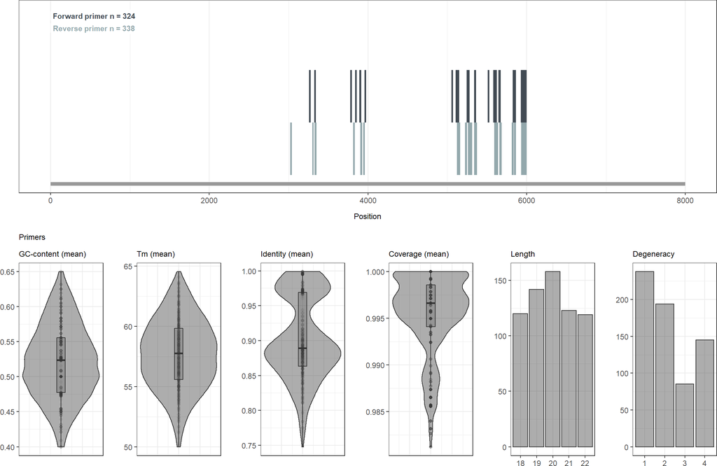

```r
plotData(myMaskedMixedPrimers)
```

For mixed primers, identity refers to the average identity within the 5’ consensus part of the primer binding region, and coverage refers to the average coverage of the 3’ degenerate part of the primer. For ambiguous primers (and probes), both of these values are calculated for the oligo as a whole. For a detailed explanation of identity and coverage, see Step 1.

**Scoring system**

All valid oligos are scored based on their average identity, coverage, and GC-content. The score can range from 0 to 9, where 0 is considered best. You can find more information about the scoring system in the manual (`?oligos`).

The best scoring oligos can be retrieved as follows:

```r
## Get the minimum score from myOligos
bestOligoScore <- min(myOligos$score)
bestOligoScore
```

```
#> [1] 0
```

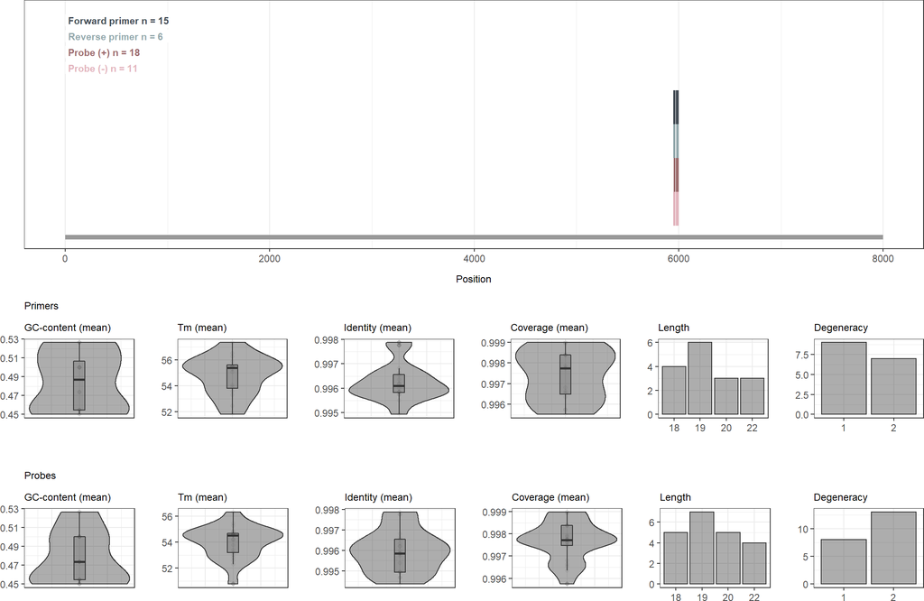

```r
## Make a subset that only oligos with the best score are included
oligoSelection <- myOligos[myOligos$score == bestOligoScore, ]

## Plot these oligos
plotData(oligoSelection)
```

**Oligo binding regions**

It is possible to select a specific oligo and plot the nucleotide distribution within the binding region, by subsetting the consensus profile from Step 1:

```r
## Get the binding region of the first oligo in the selection above (first row):
bindingRegion <- myConsensusProfile[
  myConsensusProfile$position >= oligoSelection[1, ]$start &
    myConsensusProfile$position <= oligoSelection[1, ]$end,
  ]
```

It can be plotted in forward direction:

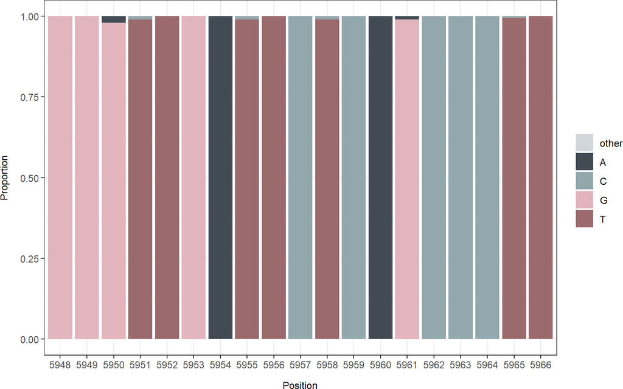

```r
plotData(bindingRegion, type = "nucleotide")
```

Or as reverse complement, by specifying `rc = TRUE`:

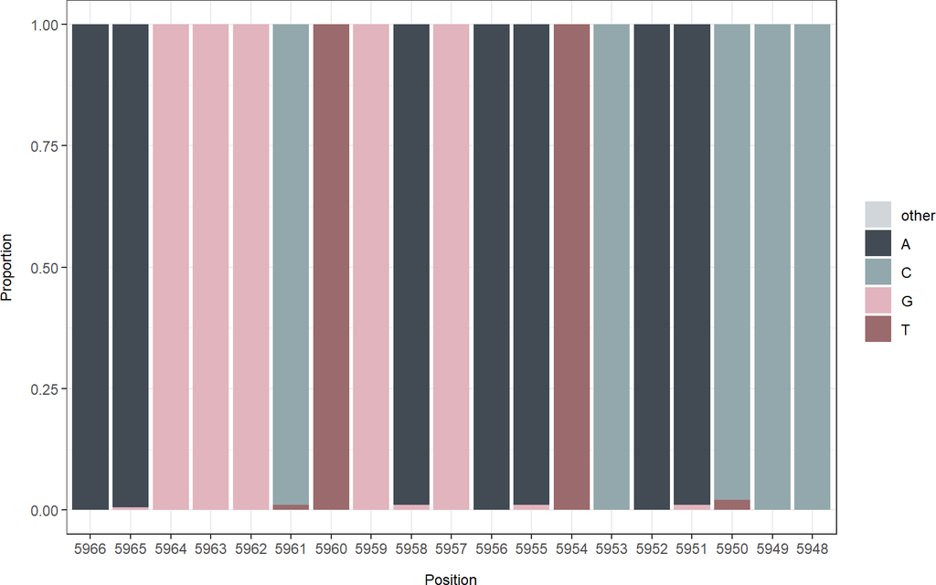

```r
plotData(bindingRegion, type = "nucleotide", rc = TRUE)
```

### 5.3.3 Step 3: `assays`

The final step is to find pairs of forward and reverse primers, and eventually, to combine them with probes. If probes are present in the input dataset, only assays with a probe present between the primer pair will be kept.

- `x`: the oligo dataset from Step 2
- `length`: amplicon length range, defaults to `c(65, 120)`
- `tmDifferencePrimers`: maximum allowed difference between the mean tm of the forward and reverse primer (in Celcius degrees). Defaults to `NULL`, which means that primers will be paired regardless of their tm.

  Note that the strategy of matching primer tm is somewhat flawed: what in reality is of interest is the amount of primer bound at the annealing temperature (ta). A PCR is most efficient if the two primers hybridize to the target at the same extent at the ta, see (SantaLucia 2007) for how to calculate the proportion of hybridized primer at different temperatures.

An error message will return if no assays are found.

Below, I show how to design assays using default settings using the dataset `myOligos` from Step 2:

```r
myAssays <- assays(myOligos)
```

Output (first ten rows):

| start | end | length | totalDegeneracy | score | startFwd | endFwd | lengthFwd | iupacSequenceFwd | identityFwd | coverageFwd | degeneracyFwd | gcContentMeanFwd | gcContentRangeFwd | tmMeanFwd | tmRangeFwd | deltaGMeanFwd | deltaGRangeFwd | sequenceFwd | gcContentFwd | tmFwd | deltaGFwd | methodFwd | startRev | endRev | lengthRev | iupacSequenceRev | identityRev | coverageRev | degeneracyRev | … |
| --- | --- | --- | --- | --- | --- | --- | --- | --- | --- | --- | --- | --- | --- | --- | --- | --- | --- | --- | --- | --- | --- | --- | --- | --- | --- | --- | --- | --- | --- | --- |
| 5926 | 5994 | 69 | 6 | 2.00 | 5926 | 5945 | 20 | GGCRGTGGTTTCTGGGGTGA | 0.98 | 1 | 2 | 0.62 | 0.05 | 62.84 | 2.51 | -20.86 | 1.25 | GGCAGTGG…. | 0.6, 0.65 | 61.57995…. | -20.2350…. | ambiguous | 5975 | 5994 | 20 | GTTGGTTGGATGAASATAGG | 1 | 1 | 2 | … |
| 5926 | 5994 | 69 | 6 | 2.33 | 5926 | 5945 | 20 | GGCRGTGGTTTCTGGGGTGA | 0.98 | 1 | 2 | 0.62 | 0.05 | 62.84 | 2.51 | -20.86 | 1.25 | GGCAGTGG…. | 0.6, 0.65 | 61.57995…. | -20.2350…. | ambiguous | 5975 | 5994 | 20 | GTTGGTTGGATGAASATAGG | 1 | 1 | 2 | … |
| 5926 | 5994 | 69 | 6 | 2.00 | 5926 | 5945 | 20 | GGCRGTGGTTTCTGGGGTGA | 0.98 | 1 | 2 | 0.62 | 0.05 | 62.84 | 2.51 | -20.86 | 1.25 | GGCAGTGG…. | 0.6, 0.65 | 61.57995…. | -20.2350…. | ambiguous | 5975 | 5994 | 20 | GTTGGTTGGATGAASATAGG | 1 | 1 | 2 | … |
| 5926 | 5994 | 69 | 6 | 1.67 | 5926 | 5945 | 20 | GGCRGTGGTTTCTGGGGTGA | 0.98 | 1 | 2 | 0.62 | 0.05 | 62.84 | 2.51 | -20.86 | 1.25 | GGCAGTGG…. | 0.6, 0.65 | 61.57995…. | -20.2350…. | ambiguous | 5975 | 5994 | 20 | GTTGGTTGGATGAASATAGG | 1 | 1 | 2 | … |
| 5926 | 5994 | 69 | 6 | 2.00 | 5926 | 5945 | 20 | GGCRGTGGTTTCTGGGGTGA | 0.98 | 1 | 2 | 0.62 | 0.05 | 62.84 | 2.51 | -20.86 | 1.25 | GGCAGTGG…. | 0.6, 0.65 | 61.57995…. | -20.2350…. | ambiguous | 5975 | 5994 | 20 | GTTGGTTGGATGAASATAGG | 1 | 1 | 2 | … |
| 5926 | 5994 | 69 | 6 | 2.00 | 5926 | 5945 | 20 | GGCRGTGGTTTCTGGGGTGA | 0.98 | 1 | 2 | 0.62 | 0.05 | 62.84 | 2.51 | -20.86 | 1.25 | GGCAGTGG…. | 0.6, 0.65 | 61.57995…. | -20.2350…. | ambiguous | 5975 | 5994 | 20 | GTTGGTTGGATGAASATAGG | 1 | 1 | 2 | … |
| 5926 | 5994 | 69 | 6 | 2.00 | 5926 | 5945 | 20 | GGCRGTGGTTTCTGGGGTGA | 0.98 | 1 | 2 | 0.62 | 0.05 | 62.84 | 2.51 | -20.86 | 1.25 | GGCAGTGG…. | 0.6, 0.65 | 61.57995…. | -20.2350…. | ambiguous | 5975 | 5994 | 20 | GTTGGTTGGATGAASATAGG | 1 | 1 | 2 | … |
| 5926 | 5994 | 69 | 6 | 1.67 | 5926 | 5945 | 20 | GGCRGTGGTTTCTGGGGTGA | 0.98 | 1 | 2 | 0.62 | 0.05 | 62.84 | 2.51 | -20.86 | 1.25 | GGCAGTGG…. | 0.6, 0.65 | 61.57995…. | -20.2350…. | ambiguous | 5975 | 5994 | 20 | GTTGGTTGGATGAASATAGG | 1 | 1 | 2 | … |
| 5926 | 5994 | 69 | 6 | 1.67 | 5926 | 5945 | 20 | GGCRGTGGTTTCTGGGGTGA | 0.98 | 1 | 2 | 0.62 | 0.05 | 62.84 | 2.51 | -20.86 | 1.25 | GGCAGTGG…. | 0.6, 0.65 | 61.57995…. | -20.2350…. | ambiguous | 5975 | 5994 | 20 | GTTGGTTGGATGAASATAGG | 1 | 1 | 2 | … |
| 5926 | 5994 | 69 | 6 | 2.00 | 5926 | 5945 | 20 | GGCRGTGGTTTCTGGGGTGA | 0.98 | 1 | 2 | 0.62 | 0.05 | 62.84 | 2.51 | -20.86 | 1.25 | GGCAGTGG…. | 0.6, 0.65 | 61.57995…. | -20.2350…. | ambiguous | 5975 | 5994 | 20 | GTTGGTTGGATGAASATAGG | 1 | 1 | 2 | … |

The output contains many columns, but you can get an overview by calling `View(as.data.frame(myAssays))` if you are working in RStudio.

Again, the results can be visualized using `plotData()`:

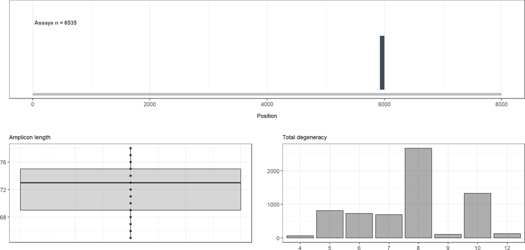

```r
plotData(myAssays)
```

We now have over 1000 assays, but the number can be reduced by filtering the dataset. In the example below, I select to subset the assays based on their average oligo score (see the score variable in the table above) so that only the assays with the best score are kept.

The best possible average score is 0 and the worst possible score is 9 (see Step 2 for more information).

```r
## Get the minimum (best) score from myAssays
bestAssayScore <- min(myAssays$score)
bestAssayScore
```

```
#> [1] 0.6666667
```

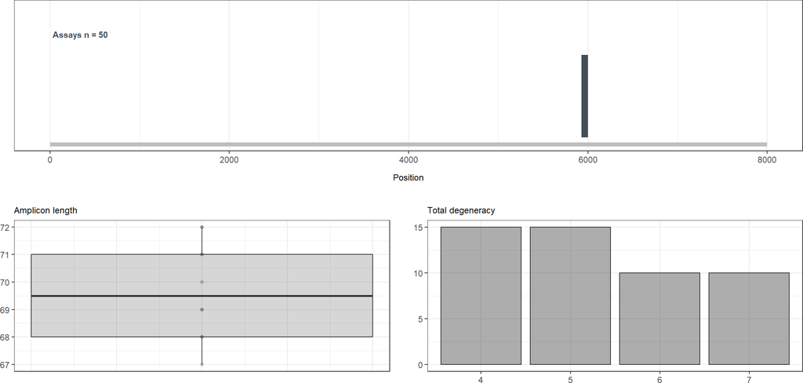

```r
## Make a subset that only contains the assays with the best score
myAssaySelection <- myAssays[myAssays$score == bestAssayScore, ]

## Plot these assays
plotData(myAssaySelection)
```

## 5.4 Further handling of the data

### 5.4.1 Oligo and assay binding regions

Oligo and assay binding region(s) can be inspected in more detail by using the consensus profile from Step 1. As an example, I select to take a closer look at the first assay in `myAssaySelection` from Step 3.

The start and end position of an assay can be retrieved as follows:

```r
from <- myAssaySelection[1, ]$start
to <- myAssaySelection[1, ]$end
```

It is now possible to indicate the amplicon region, using the `highlight` argument in `plotData()`:

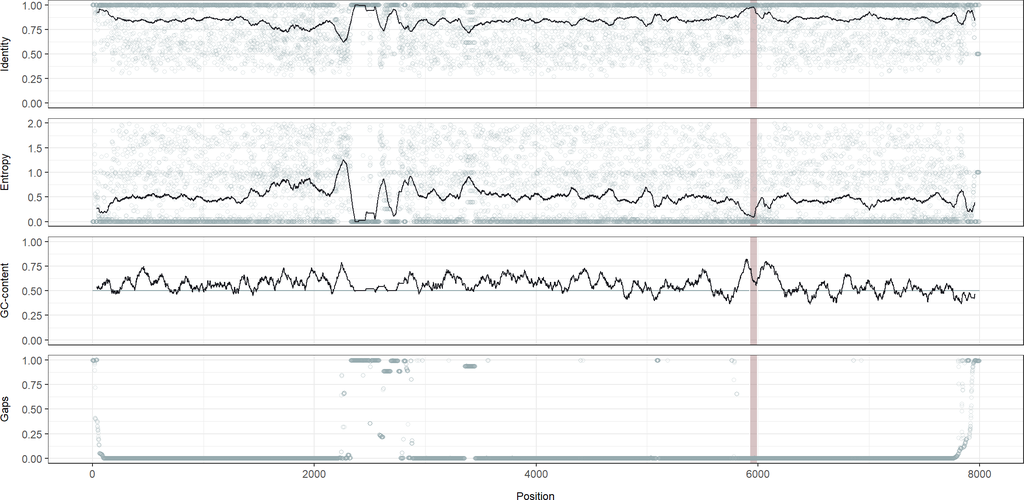

```r
plotData(myConsensusProfile, highlight = c(from, to))
```

To get a more detailed view, we can make a subset of the consensus profile to only contain the amplicon region, and plot it:

```r
myAssayRegion <- myConsensusProfile[
  myConsensusProfile$position >= from &
    myConsensusProfile$position <= to,
]
```

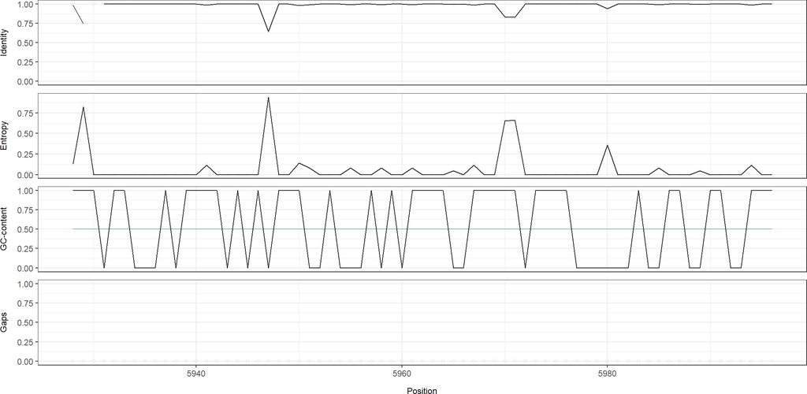

```r
plotData(myAssayRegion)
```

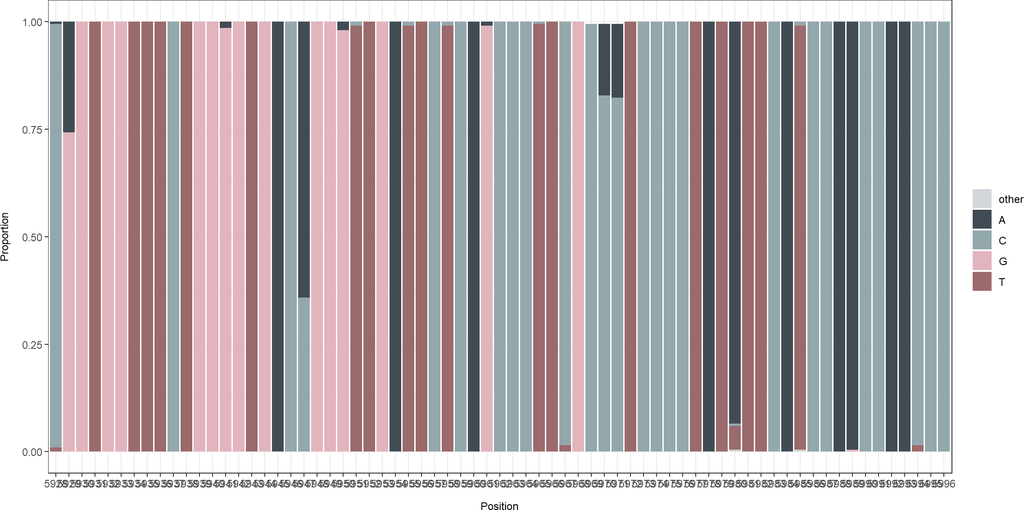

```r
plotData(myAssayRegion, type = "nucleotide")
```

The consensus amplicon sequence is obtained as follows:

```r
paste(myAssayRegion$iupac, collapse = "")
```

```
#> [1] "CRGTGGTTTCTGGGGTGACMGGGTTGATTCTCAGCCCTTCGCMMTCCCCTATWTTCATCCAACCAACCC"
```

### 5.4.2 Check match

It is often valuable to investigate how the generated oligos or assays match with their target sequences. `checkMatch()` can be used for this purpose. The function is a wrapper to `Biostrings::vcountPDict()` (Pagès et al. 2020) and has two arguments:

- `x`: an oligo or assay dataset from Step 2 or 3
- `target`: the target alignment used as input in Step 1

The output gives information on the proportion and names of target sequences that match perfectly and with one, two, three, or four or more mismatches to the oligo *within* the intended oligo binding region in the alignment (on-target match). It also tells the proportion and names of target sequences that match with a maximum of two mismatches to the oligo *outside* the intended oligo binding region (off-target match). Thus, be cautious that false negatives (or positives) may occur due to poorly aligned sequences. Moreover, the output does not tell what strand (minus or plus) the oligo matches to, which is important to consider when assessing off-target matches to single-stranded targets. See the manual (`?checkMatch`) for more information.

Ambiguous bases and gaps in the target sequences will be identified as mismatches.

Below, I show how to use `checkMatch()` for both oligos and assays. The function is rather slow, especially if there are many target sequences, so a good idea could be to select only a few oligo or assay candidates to investigate.

**Oligos**

```r
## I take only the first five for the brevity of this example
oligoSelectionMatch <- checkMatch(oligoSelection[1:5, ], target = myAlignment)
```

Output:

| iupacSequence | perfectMatch | idPerfectMatch | oneMismatch | idOneMismatch | twoMismatches | idTwoMismatches | threeMismatches | idThreeMismatches | fourOrMoreMismatches | idFourOrMoreMismatches | offTargetMatch | idOffTargetMatch |
| --- | --- | --- | --- | --- | --- | --- | --- | --- | --- | --- | --- | --- |
| GGGTTGATTCTCAGCCCTT | 0.93 | M73218.1…. | 0.07 | AB222183…. | 0.00 |  | 0 |  | 0 |  | 0 |  |
| GGGTTGATTCTCAGCCCTT | 0.93 | M73218.1…. | 0.07 | AB222183…. | 0.00 |  | 0 |  | 0 |  | 0 |  |
| GGTTGATTCTCAGCCCTT | 0.93 | M73218.1…. | 0.07 | AB222183…. | 0.00 |  | 0 |  | 0 |  | 0 |  |
| GGTTGATTCTCAGCCCTTC | 0.92 | M73218.1…. | 0.07 | AY575857…. | 0.01 | AB222183.1 | 0 |  | 0 |  | 0 |  |
| GGTTGATTCTCAGCCCTT | 0.93 | M73218.1…. | 0.07 | AB222183…. | 0.00 |  | 0 |  | 0 |  | 0 |  |

Note that the id-variables can hold several values in each row. All values can be retrieved by:

```r
## Get the id of all sequences that has one mismatch to the first oligo in the input dataset
oligoSelectionMatch$idOneMismatch[[1]]
```

```
#>  [1] "AB222183.1" "AY575857.1" "AB481228.1" "MN614430.1" "KT727028.1"
#>  [6] "KJ701409.1" "JQ953665.1" "KP698919.1" "AB291966.1" "LC042232.1"
#> [11] "AB521805.1" "AB602441.1" "AB573435.2"
```

The output can be visualized using `plotData()`:

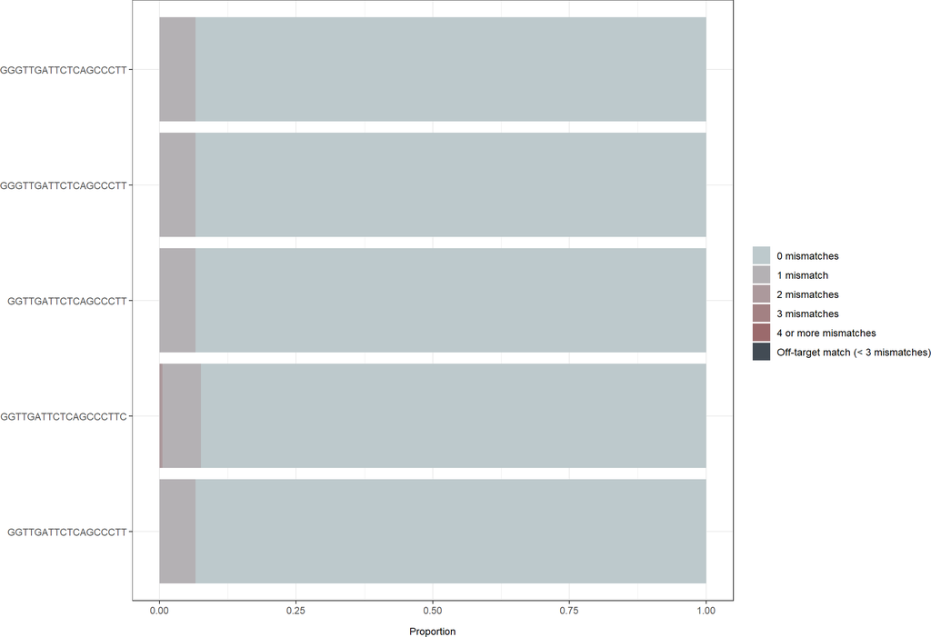

```r
plotData(oligoSelectionMatch)
```

**Assays**

```r
## Select the assays with the best (lowest) score
assaySelection <- myAssays[myAssays$score == min(myAssays$score), ]

## I take only the first five for the brevity of this example
assaySelectionMatch <- checkMatch(assaySelection[1:5, ], target = myAlignment)
```

Output:

| iupacSequenceFwd | perfectMatchFwd | idPerfectMatchFwd | oneMismatchFwd | idOneMismatchFwd | twoMismatchesFwd | idTwoMismatchesFwd | threeMismatchesFwd | idThreeMismatchesFwd | fourOrMoreMismatchesFwd | idFourOrMoreMismatchesFwd | offTargetMatchFwd | idOffTargetMatchFwd | iupacSequenceRev | perfectMatchRev | idPerfectMatchRev | oneMismatchRev | idOneMismatchRev | twoMismatchesRev | idTwoMismatchesRev | threeMismatchesRev | idThreeMismatchesRev | fourOrMoreMismatchesRev | idFourOrMoreMismatchesRev | offTargetMatchRev | idOffTargetMatchRev | iupacSequencePr | perfectMatchPr | idPerfectMatchPr | oneMismatchPr | … |
| --- | --- | --- | --- | --- | --- | --- | --- | --- | --- | --- | --- | --- | --- | --- | --- | --- | --- | --- | --- | --- | --- | --- | --- | --- | --- | --- | --- | --- | --- | --- |
| CRGTGGTTTCTGGGGTGA | 0.97 | M73218.1…. | 0.03 | BD378055…. | 0 |  | 0 |  | 0 |  | 0 |  | GGGTTGGTTGGATGAASATAGG | 0.95 | M73218.1…. | 0.05 | AY575857…. | 0 |  | 0 |  | 0 |  | 0 |  | GGGTTGATTCTCAGCCCTT | 0.93 | M73218.1…. | 0.07 | … |
| CRGTGGTTTCTGGGGTGA | 0.97 | M73218.1…. | 0.03 | BD378055…. | 0 |  | 0 |  | 0 |  | 0 |  | GGGTTGGTTGGATGAASATAGG | 0.95 | M73218.1…. | 0.05 | AY575857…. | 0 |  | 0 |  | 0 |  | 0 |  | GGTTGATTCTCAGCCCTT | 0.93 | M73218.1…. | 0.07 | … |
| CRGTGGTTTCTGGGGTGA | 0.97 | M73218.1…. | 0.03 | BD378055…. | 0 |  | 0 |  | 0 |  | 0 |  | GGGTTGGTTGGATGAASATAGG | 0.95 | M73218.1…. | 0.05 | AY575857…. | 0 |  | 0 |  | 0 |  | 0 |  | GTTGATTCTCAGCCCTTCG | 0.92 | M73218.1…. | 0.07 | … |
| CRGTGGTTTCTGGGGTGA | 0.97 | M73218.1…. | 0.03 | BD378055…. | 0 |  | 0 |  | 0 |  | 0 |  | GGGTTGGTTGGATGAASATAGG | 0.95 | M73218.1…. | 0.05 | AY575857…. | 0 |  | 0 |  | 0 |  | 0 |  | TTGATTCTCAGCCCTTCG | 0.94 | M73218.1…. | 0.05 | … |
| CRGTGGTTTCTGGGGTGA | 0.97 | M73218.1…. | 0.03 | BD378055…. | 0 |  | 0 |  | 0 |  | 0 |  | GGGTTGGTTGGATGAASATAGG | 0.95 | M73218.1…. | 0.05 | AY575857…. | 0 |  | 0 |  | 0 |  | 0 |  | TTGATTCTCAGCCCTTCGC | 0.94 | M73218.1…. | 0.06 | … |

The output can be visualized using `plotData()`:

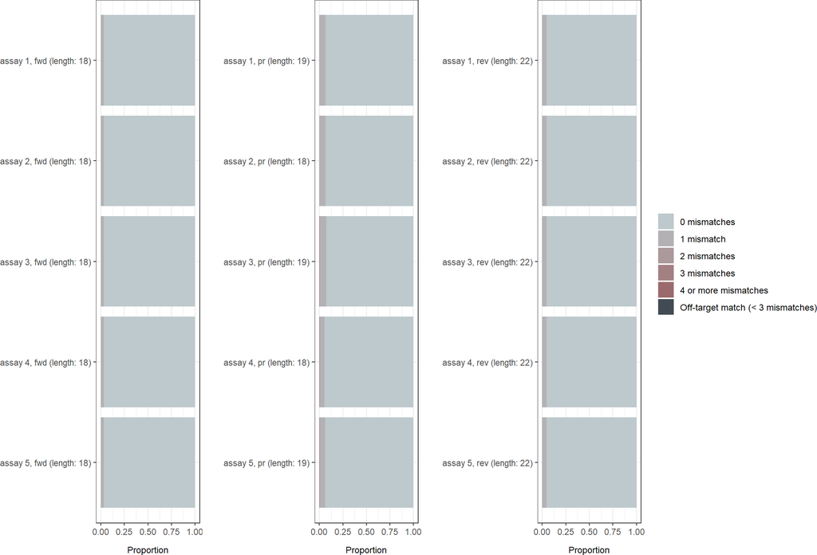

```r
plotData(assaySelectionMatch)
```

## 5.5 Export to file

Before proceeding to wet lab evaluation, it is highly recommended to evaluate the final primer and probe candidates for 1) the potential to form primer dimers and hairpin structures, and 2) the potential to (not) cross react with non-targets.

These tasks are best performed by other software. Below, I show how to export results to a file so they can be readily analyzed by other tools.

**Result tables**

All result tables can be saved to .txt or .csv-files, for instance:

```r
write.csv(myAssays, file = "myAssays.csv", quote = FALSE, row.names = FALSE)
write.table(myAssays, file = "myAssays.txt", quote = FALSE, row.names = FALSE)
```

**Oligos and assays to fasta format**

It is also possible to export the oligo sequences in fasta-format. To do this, the oligo or assay(s) of interest must first be cocered to a `Biostrings::DNAStringSet` object, as follows:

```r
## Convert the first two oligos
as(myOligos[1:2, ], "DNAStringSet")
```

```
#> DNAStringSet object of length 6:
#>     width seq                                               names
#> [1]    20 TCCGCCCTGGCGAATGCTGT                              oligo_1_variant_1
#> [2]    20 TCTGCCCTGGCGAATGCTGT                              oligo_1_variant_2
#> [3]    20 TCCGCCTTGGCGAATGCTGT                              oligo_1_variant_3
#> [4]    20 TCTGCCTTGGCGAATGCTGT                              oligo_1_variant_4
#> [5]    20 GCCCTGGCGAATGCTGTGGT                              oligo_2_variant_1
#> [6]    20 GCCTTGGCGAATGCTGTGGT                              oligo_2_variant_2
```

```r
## Convert the first two assays
as(myAssays[1:2, ], "DNAStringSet")
```

```
#> DNAStringSet object of length 12:
#>      width seq                                              names
#>  [1]    20 GGCAGTGGTTTCTGGGGTGA                             assay_1_fwd_varia...
#>  [2]    20 GGCGGTGGTTTCTGGGGTGA                             assay_1_fwd_varia...
#>  [3]    20 GGCAGTGGTTTCTGGGGTGA                             assay_2_fwd_varia...
#>  [4]    20 GGCGGTGGTTTCTGGGGTGA                             assay_2_fwd_varia...
#>  [5]    20 CCTATATTCATCCAACCAAC                             assay_1_rev_varia...
#>  ...   ... ...
#>  [8]    20 CCTATTTTCATCCAACCAAC                             assay_2_rev_varia...
#>  [9]    18 CAGGGTTGATTCTCAGCC                               assay_1_pr_variant_1
#> [10]    18 CCGGGTTGATTCTCAGCC                               assay_1_pr_variant_2
#> [11]    19 CAGGGTTGATTCTCAGCCC                              assay_2_pr_variant_1
#> [12]    19 CCGGGTTGATTCTCAGCCC                              assay_2_pr_variant_2
```

Note that all sequences will be written in the same direction as the input target alignment, and all sequence variants of each oligo will be printed.

The sequences can now be saved in fasta format, for example:

```r
toFile <- as(myOligos[1:2, ], "DNAStringSet")
Biostrings::writeXStringSet(toFile, file = "myOligos.txt")
```

# 6 Summary

The design process is summarized below.

Using the R console:

```r
library(rprimer)

## Enter the filepath to an alignment with target sequences of interest
filepath <- system.file("extdata", "example_alignment.txt", package = "rprimer")

## Import the alignment
myAlignment <- Biostrings::readDNAMultipleAlignment(filepath, format = "fasta")

## Design primers, probes and assays (modify settings if needed)
myConsensusProfile <- consensusProfile(myAlignment, ambiguityThreshold = 0.05)
myOligos <- oligos(myConsensusProfile)
myAssays <- assays(myOligos)

## Visualize the results
plotData(myConsensusProfile)
plotData(myOligos)
plotData(myAssays)

## Show result tables (in RStudio)
View(as.data.frame(myConsensusProfile))
View(as.data.frame(myOligos))
View(as.data.frame(myAssays))
```

Using the Shiny application:

```r
library(rprimer)

## Start application
runRprimerApp()
```

# 7 Classes and example data

The “Rprimer” classes (`RprimerProfile`, `RprimerOligo`, `RprimerAssay`, `RprimerMatchOligo` and `RprimerMatchAssay`) extends the `DataFrame` class from S4Vectors (Pagès, Lawrence, and Aboyoun 2017), and behave in a similar way as traditional data frames, with methods for `[`, `$`, `nrow()`, `ncol()`, `head()`, `tail()`, `rbind()`, `cbind()` etc. They can be coerced to traditional data frames by using `as.data.frame()`.

Example datasets of each class are provided with the package, and are loaded by:

```r
data("exampleRprimerProfile")
data("exampleRprimerOligo")
data("exampleRprimerAssay")
data("exampleRprimerMatchOligo")
data("exampleRprimerMatchAssay")
```

To provide reproducible examples, I have also included an alignment of class `Biostrings::DNAMultipleAlignment`. It is loaded by `data("exampleRprimerAlignment")`.

# 8 Table values

Tables used for determination of complement bases, IUPAC consensus character codes, degeneracy and nearest neighbors can be found by typing:

- `rprimer:::lookup$complement`
- `rprimer:::lookup$iupac`, `rprimer:::lookup$degenerates`,
- `rprimer:::lookup$degeneracy` and
- `rprimer:::lookup$nn`, respectively.

# 9 Source code

The source code is available at https://github.com/sofpn/rprimer.

# 10 Citation

To cite this package, please use: `citation("rprimer")`.

# 11 Session info

# References

Pagès, H, P Aboyoun, R Gentleman, and S DebRoy. 2020. “Biostrings: Efficient Manipulation of Biological Strings(bioconductor Version: Release(3.10), 2020) Https:/Doi. Org/10.18129/B9. Bioc.” *Biostrings (April 28, 2020)*.

Pagès, H, M Lawrence, and P Aboyoun. 2017. “S4Vectors: S4 Implementation of Vectors and Lists.” *R Package Version 0.13* 15.

Rose, TM, ER Schultz, JG Henikoff, S Pietrokovski, CM McCallum, and S Henikoff. 1998. “Consensus-Degenerate Hybrid Oligonucleotide Primers for Amplification of Distantly Related Sequences.” *Nucleic Acids Research* 26 (7): 1628–35.

SantaLucia, J. 1998. “A Unified View of Polymer, Dumbbell, and Oligonucleotide DNA Nearest-Neighbor Thermodynamics.” *Proceedings of the National Academy of Sciences* 95 (4): 1460–65.

———. 2007. “Physical Principles and Visual-OMP Software for Optimal PCR Design.” *PCR Primer Design*, 3–33.

SantaLucia, J, and D Hicks. 2004. “The Thermodynamics of DNA Structural Motifs.” *Annu. Rev. Biophys. Biomol. Struct.* 33: 415–40.

Shannon, C. 1951. “Prediction and Entropy of Printed English.” *Bell System Technical Journal* 30 (1): 50–64.